# Stock Volatility Analysis

Optiver24

2023-05-28

# Stock Volatility Analysis

## 1. Data Preparation

Prepare the volatility data to be trained and tested.

### 1.1 Import libraries

Import packages to be used.

```r
library(ggplot2)
library(dplyr)
library(forecast)
library(Metrics)
library(rugarch)
library(tseries)
```

### 1.2 Stock clustering

We load a pre-defined clusters of stocks here. For the final submission, we selected a total of 45 stocks from 10 clusters. This results from the stock clustering file, `Advanced Volatility Clustering V2.Rmd`.

```r
stocks_to_analyze <- get(load("stocks_to_analyze_df.RData"))
group_lis <- split(stocks_to_analyze_df, stocks_to_analyze_df$cluster)
selected_stocks <- stocks_to_analyze_df$stock_id
selected_stocks
```

### 1.3 Define global variables

Define the important global variables to be used in the project here to change the settings easily.

```r
# Global variables
SECOND.PER.BUCKET <- 10 # number of seconds per time bucket
stock_ids <- as.character(selected_stocks)
num.stocks <- length(stock_ids)
stock_data_dir <- "individual_book_train"
cached_data_dir <- "cached_data/"
num.time.id <- 500 # number of time ids to be analysed
```

## 2. Volatility calculation

> As it may take large amount of computational time and space, you can skip this section and load cached `.RData` file for volatility directly at 2.3 Cached volatility data.

Import stock files of the selected stocks to environment.

```r
# Take a list of stock numbers, return a list of stock dataframe
load_stocks <- function(path, selected_stocks){
  stock.dic <- list()
  for (i in selected_stocks){
    filepath <- paste0(path, "/stock_", i, ".csv")
    print(filepath)
    stock <- read.csv(filepath)
    stock.dic[[i]] <- stock
  }
  return(stock.dic)
}
stock.dic.raw <- load_stocks(stock_data_dir, stock_ids)
```

### 2.1 Compute statistics from order book

Compute weighted average price (WAP), BidAskSpread, and the time bucket for all the snapshots over the selected stocks.

```r
compute_stats <- function(stock){
  stock <- stock %>% mutate(WAP = (bid_price1 * ask_size1 + ask_price1 * bid_size1) / (bid_size1 + ask_size1))
  stock <- stock %>% mutate(BidAskSpread = ask_price1 / bid_price1 - 1)
  stock <- stock %>% mutate(time_bucket = ceiling(seconds_in_bucket / SECOND.PER.BUCKET))
  return(stock)
}

stock.dic <- list()
for (stock_id in stock_ids){
  print(paste0("Computing stats for stock_", stock_id))
  stock.dic[[stock_id]] <- compute_stats(stock.dic.raw[[stock_id]])
}
```

### 2.2 Compute log returns and realised volatility

Define a function to compute log returns which takes a stock dataframe and selected time ids as input and returns a list of log-return dataframes for each time_ID.

```r
# Compute the log returns for the first n 10-min time intervals
get_log_returns <- function(stock, num_time_id, time_IDs){
  log_r1 <- list()
  for (i in 1 : length(time_IDs)) {
    sec <- stock %>% filter(time_id == time_IDs[i]) %>% pull(seconds_in_bucket)
    price <- stock %>% filter(time_id == time_IDs[i]) %>% pull(WAP)
    log_r <- log(price[-1] / price[1:(length(price) - 1)])
    log_r1[[i]] <- data.frame(time = sec[-1], log_return = log_r)
    time.no.change <- (1:600)[!(1:600 %in% log_r1[[i]]$time)]
    if (length(time.no.change) > 0) {
      new.df <- data.frame(time = time.no.change, log_return = 0)
      log_r1[[i]] <- rbind(log_r1[[i]], new.df)
      log_r1[[i]] <- log_r1[[i]][order(log_r1[[i]]$time), ]
    }
  }
  return(log_r1)
}
```

Compute log returns for the first 500 time IDs. Then, compute the realised volatility based on log returns where volatility is calculated in every 10 seconds

```r
#
comp_vol <- function(x) {
  return(sqrt(sum(x ^ 2)))
}
get_vol <- function(log_r1){
  vol <- list()
  for (i in 1 : length(log_r1)) {
    log_r1[[i]] <- log_r1[[i]] %>% mutate(time_bucket = ceiling(time / SECOND.PER.BUCKET))
    vol[[i]] <- aggregate(log_return ~ time_bucket, data = log_r1[[i]], FUN = comp_vol)
    colnames(vol[[i]]) <- c('time_bucket', 'volatility')
  }
  return(vol)
}

log.return.dic <- list() # a dictionary-like list containing log-return dataframes for stocks
for (stock_id in stock_ids){
  print(paste0("Compute log returns for stock_", stock_id))
  log.return.dic[[stock_id]]  <- get_log_returns(stock.dic[[stock_id]], num.time.id, comm_time_IDs)
}

vol.dic <- list() # a dictionary-like list containing volatility dataframes for 10 stocks
for (stock_id in stock_ids){
  print(paste0("Compute volatility for stock_", stock_id))
  vol.dic[[stock_id]] <- get_vol(log.return.dic[[stock_id]] )
}
```

Find the length of a volatility data.

```r
len.vol <- length(vol.dic[[1]][[1]]$volatility)
```

### 2.3 Cached volatility data

Load pre-computed volatility data.

```r
vol.dic <- get(load(paste0(cached_data_dir, "vol_dic.RData")))
len.vol <- length(vol.dic[[1]][[1]]$volatility)

comm_time_IDs <- get(load(paste0(cached_data_dir, "comm_time_IDs.RData")))
```

### 2.4 Volatility visualisation

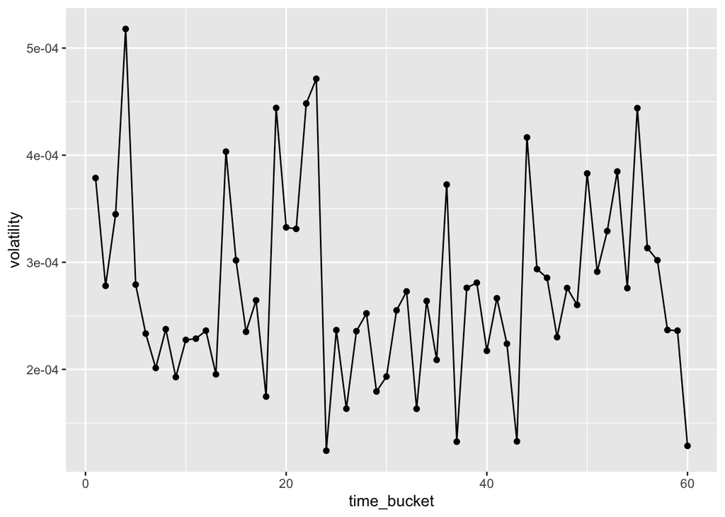

```r
ggplot(data = vol.dic[[1]][[1]], aes(x = time_bucket, y = volatility)) + geom_line() + geom_point()
```

## 3. Volatility Prediction

> To skip the training and predicting processes, you can load cached predictions at 3.7 Cached trained models and predictions

### 3.1 Autocorrelation

Conduct a preliminary analysis on the autocorrelation function (ACF) of the time series on realised volatility. The first selected stock at the first time ID is used.

```r
acf(vol.dic[[1]][[1]]$volatility, main = "ACF plot for realised volatility")
```

[output not shown]

PACF plot.

```r
pacf(vol.dic[[1]][[1]]$volatility, main = "PACF plot for realised volatility")
```

[output not shown]

### 3.2 Train-test split

Split the volatility data by 80% for training and 20% for testing, i.e. the first 8 minutes of time series data at a time ID used to fit the model and the rest 2 minutes are used to validate the prediction made by models.

```r
vol.train.dic <- list()
vol.val.dic <- list()

n_start <- ceiling(nrow(vol.dic[[1]][[1]]) * 0.8)

for (stock_id in stock_ids) {
  vol.train.dic[[stock_id]] <- list()
  vol.val.dic[[stock_id]] <- list()
  for (i in 1 : num.time.id) {
    vol.train.dic[[stock_id]][[i]] <- vol.dic[[stock_id]][[i]][1:n_start, ]
    vol.val.dic[[stock_id]][[i]] <- vol.dic[[stock_id]][[i]][-(1:n_start), ]
  }
}
len.train <- length(vol.train.dic[[1]][[1]]$volatility)
len.val <- length(vol.val.dic[[1]][[1]]$volatility)
```

*Cached training data and testing data.*

```r
vol.train.dic <- get(load(paste0(cached_data_dir, "vol_train_dic.RData")))
vol.val.dic <- get(load(paste0(cached_data_dir, "vol_val_dic.RData")))
len.train <- length(vol.train.dic[[1]][[1]]$volatility)
len.val <- length(vol.val.dic[[1]][[1]]$volatility)
```

### 3.3 Assumption checking for time series data

```r
# Assume `vol.train.dic` is your time-series data
tsdata <- vol.train.dic[[1]][[1]]$volatility

# Augmented Dickey-Fuller test for stationarity
adf.test(tsdata)
```

```
##
##  Augmented Dickey-Fuller Test
##
## data:  tsdata
## Dickey-Fuller = -3.4636, Lag order = 3, p-value = 0.05745
## alternative hypothesis: stationary
```

```r
# Ljung-Box test for autocorrelation in residuals
Box.test(tsdata, type = "Ljung-Box")
```

```
##
##  Box-Ljung test
##
## data:  tsdata
## X-squared = 0.50912, df = 1, p-value = 0.4755
```

```r
# KPSS test for order of differencing
kpss.test(tsdata)
```

```
##
##  KPSS Test for Level Stationarity
##
## data:  tsdata
## KPSS Level = 0.18155, Truncation lag parameter = 3, p-value = 0.1
```

```r
# Engle's ARCH test for constant variance
# rugarch::arch.test(tsdata)
```

### 3.4 ARIMA

Fit ARIMA model with order(0, 0, 10).

```r
# Train
arima.model.dic <- list() # contains arima models
for (stock_id in stock_ids) {
  print(paste0("Training ARIMA with stock_", stock_id))
  arima.model.dic[[stock_id]] <- list()
  for (i in 1 : num.time.id) {
    train_data <- vol.train.dic[[stock_id]][[i]]$volatility
    arima.model.dic[[stock_id]][[i]] <- arima(train_data, order = c(0, 0, 10))
    # auto.arima(train_data, ic = "aic")
    # can try run with defined orders here, such as `arima(train_data, order=c(1,0,1))`, compare performance metrices
  }
}
```

Apply ARIMA model to predict volatility.

```r
# Predict
arima.pred.dic <- list()
for (stock_id in stock_ids) {
  print(paste0("Using ARIMA predict stock_", stock_id))
  arima.pred.dic[[stock_id]] <- list()
  for (i in 1 : num.time.id) {
    model <- arima.model.dic[[stock_id]][[i]]
    arima.pred.dic[[stock_id]][[i]] <- (forecast(model, h = len.val)$mean)
  }
}
```

### 3.5 Linear regression model

#### 3.5.1 Traing set set preparation

Add features for linear regression, i.e. imbalance, number of orders.

```r
reg.stock.dic <- list()
for (stock_id in stock_ids){
  stock <- stock.dic[[stock_id]]
  stock <- stock %>% mutate(num_order = bid_size1 + ask_size1 + bid_size2 + ask_size2)
  stock <- stock %>% mutate(imbalance = ((bid_size1 + bid_size2) - (ask_size1 + ask_size2))/ num_order )
  reg.stock.dic[[stock_id]] <- stock
}
```

For all selected stocks and all 500 time_IDs, construct a data frame for training and validation. For each 10-sec time buckect, we compute the `mean.price`, `mean.order`, `mean.BAS`, `mean.imbalance`, `sd.price`, `sd.BAS`, and `sd.imbalance`.

```r
# construct training set and validation set for linear regression
reg.train.dic <- list()
reg.val.dic <- list()

for (stock_id in stock_ids) {
  print(paste0("Processing on stock_", stock_id))

  # retrieve vol table and stock table from dictionaries
  stock <- reg.stock.dic[[stock_id]]
  vol.train <- vol.train.dic[[stock_id]]
  vol.val <- vol.val.dic[[stock_id]]

  # initialise the stock_id of 500 regression training sets for stock `stock_id`
  reg.train.dic[[stock_id]] <- list()
  reg.val.dic[[stock_id]] <- list()

  for (i in 1 : num.time.id) {
    stats.bucket <- stock %>%
      filter(time_id == comm_time_IDs[i] & time_bucket != 0) %>%
      dplyr::select(c(BidAskSpread, WAP, num_order, time_bucket, imbalance))

    # For each 10-sec time bucket, we compute the following statistics.
    mean.price <- aggregate(WAP ~ time_bucket, data = stats.bucket, FUN = mean)
    mean.order <- aggregate(num_order ~ time_bucket, data = stats.bucket, FUN = mean)
    mean.BAS <- aggregate(BidAskSpread ~ time_bucket, data = stats.bucket, FUN = mean)
    mean.imbalance <- aggregate(imbalance ~ time_bucket, data = stats.bucket, FUN = mean)
    sd.price <- aggregate(WAP ~ time_bucket, data = stats.bucket, FUN = sd)
    sd.BAS <- aggregate(BidAskSpread ~ time_bucket, data = stats.bucket, FUN = sd)
    sd.imbalance <- aggregate(imbalance ~ time_bucket, data = stats.bucket, FUN = sd)

    # Replace NA values with 0
    sd.price$WAP[is.na(sd.price$WAP)] <- 0
    sd.BAS$BidAskSpread[is.na(sd.BAS$BidAskSpread)] <- 0
    sd.imbalance$imbalance[is.na(sd.imbalance$imbalance)] <- 0

    # Data frame for training set
    train.idx <- 1:(len.train - 1)
    train.df <- data.frame(volatility = vol.train[[i]]$volatility[-1],
                                price = mean.price$WAP[train.idx],
                                order = mean.order$num_order[train.idx],
                                BidAskSpread = mean.BAS$BidAskSpread[train.idx],
                                imbalance = mean.imbalance$imbalance[train.idx],
                                priceSD = sd.price$WAP[train.idx],
                                spreadSD = sd.BAS$BidAskSpread[train.idx],
                                imbalanceSD = sd.imbalance$imbalance[train.idx])
    # Data frame for validation set
    val.idx <- len.train:(len.train + len.val - 1)
    val.df <- data.frame(volatility = vol.val[[i]]$volatility,
               price = mean.price$WAP[val.idx],
               order = mean.order$num_order[val.idx],
               BidAskSpread = mean.BAS$BidAskSpread[val.idx],
               imbalance = mean.imbalance$imbalance[val.idx],
               priceSD = sd.price$WAP[val.idx],
               spreadSD = sd.BAS$BidAskSpread[val.idx],
               imbalanceSD = sd.imbalance$imbalance[val.idx])

    # Assign the dataframes to the list
    reg.train.dic[[stock_id]][[i]] <- train.df
    reg.val.dic[[stock_id]][[i]] <- val.df
  }
}
```

Combine the training sets of 500 time IDs into one dataframe.

```r
# Reconstruct training set
reg.train.dic.1 <- list()
for (stock_id in stock_ids) {
  print(paste0("Processing at stock_", stock_id))
  df <- data.frame(matrix(ncol = 8, nrow = 0))
  colnames(df) <- c("volatility", "price", "order", "BidAskSpread", "imbalance", "priceSD", "spreadSD", "imbalanceSD")
  for (i in 1 : num.time.id) {
    df <- rbind(df, reg.train.dic[[stock_id]][[i]])
  }
  reg.train.dic.1[[stock_id]] <- df
}
```

#### 3.5.2 Model fitting and prediction

Cached data for training and predicting for linear regression model.

```r
reg.val.dic <- get(load(paste0(cached_data_dir, "reg_val_dic.RData")))
reg.train.dic.1 <- get(load(paste0(cached_data_dir, "reg_train_dic_1.RData")))
```

*Linear model assumption checking.*

```r
# # Assume `vol.train.dic` is your regression model
mod1 <- linear.model.dic.1[[1]]

# Durbin-Watson test for independence
library(car)
durbinWatsonTest(mod1)

# library(lmtest)
# # Breusch-Pagan test for homoscedasticity
# lmtest::bptest(mod1)

# Shapiro-Wilk test for normality of residuals
shapiro.test(resid(mod1))
```

[output not shown]

```r
lm1 <- linear.model.dic.1[[10]]
par(mfrow=c(1,2))
plot(lm1, which=c(1,2))
```

[output not shown]

Linear model prediction.

```r
# Predict
reg.pred.dic.1 <- list()
for (stock_id in stock_ids) {
  print(paste0("Predicting stock_", stock_id, " volatility using lm"))
  reg.pred.dic.1[[stock_id]] <- list()
  model <- linear.model.dic.1[[stock_id]]
  for (i in 1 : num.time.id) {
    val.data <- reg.val.dic[[stock_id]][[i]]
    pred <- predict(model, newdata = val.data)
    pred[is.na(pred)] <- 0
    reg.pred.dic.1[[stock_id]][[i]] <- pred
  }
}
```

### 3.6 HAV-RV model

Construct HAV-RV training set.

```r
hav.train.dic <- list()
for (stock_id in stock_ids) {
  print(paste0("Construct HAV training set for stock ", stock_id))
  # Initialise a list containing HAV training dataframe for stock at stock_id
  hav.train.dic[[stock_id]] <- list()
  # Retrieve the training volatility set for stock at stock_id
  vol.train <- vol.train.dic[[stock_id]]
  # how many lagged time buckets are used to take the mean as predictor
  mean_lag <- 5
  for (i in 1 : num.time.id) {
    # compute the mean vol for previous 5 time buckets
    mean.vol <- rep(0, len.train - mean_lag)
    for (j in 1 : mean_lag) {
      mean.vol <- mean.vol + vol.train[[i]]$volatility[j : (j + len.train - mean_lag - 1)] / mean_lag
    }
    hav.train.dic[[stock_id]][[i]] <- data.frame(vol = vol.train[[i]]$volatility[-(1:mean_lag)],
                                vol_1 = vol.train[[i]]$volatility[mean_lag:(len.train - 1)],
                                mean_vol_5 = mean.vol)
  }
}
```

HAV-RV training step.

```r
# Train HAV model
hav.model.dic <- list()
for (stock_id in stock_ids) {
  print(paste0("Fitting HAV model for stock_", stock_id))
  hav.model.dic[[stock_id]] <- list()
  for (i in 1 : num.time.id) {
    train_data <- hav.train.dic[[stock_id]][[i]]
    hav.model <- lm(vol ~ vol_1 + mean_vol_5, train_data)
    hav.model.dic[[stock_id]][[i]] <- hav.model
  }
}
```

HAV-RV prediction step.

```r
# Define a forecast function for HAV-RV model
# vol_set = hav.train.dic[[1]][[1]] for example
hav_forecast <- function(model, vol_set, h=len.val) {
  ret <- vector()
  vol_vec <- vol_set$vol

  # how many lagged time buckets to take the mean
  mean_lag <- 5

  for (i in 1: h) {
    lag1_vol <- vol_vec[length(vol_vec)]
    lag5_vol_mean <- mean(vol_vec[(length(vol_vec) - mean_lag + 1): length(vol_vec)])
    lagged_df <- data.frame(
      vol_1 = lag1_vol,
      mean_vol_5 = lag5_vol_mean
    )
    pred <- predict(model, lagged_df)
    ret <- c(ret, pred)
    vol_vec <- c(vol_vec, pred)
  }
  return(ret)
}

# Predict HAV-RV
hav.pred.dic <- list()
for (stock_id in stock_ids) {
  print(paste0("Using HAV-RV predict stock_", stock_id))
  hav.pred.dic[[stock_id]] <- list()
  for (i in 1 : num.time.id) {
    model <- hav.model.dic[[stock_id]][[i]]
    vol_set <- hav.train.dic[[stock_id]][[i]]
    hav.pred.dic[[stock_id]][[i]] <- hav_forecast(model, vol_set)
  }
}
```

### 3.7 ARMA-GARCH

```r
# Train
library(rugarch)
garch.model.dic <- list() # contains garch models
for (stock_id in stock_ids) {
  print(paste0("Fitting GARCH at stock_", stock_id))
  vol.train.lis <- vol.train.dic[[stock_id]]
  garch.model.dic[[stock_id]] <- list()
  for (i in 1 : num.time.id) {
    train_data <- vol.train.lis[[i]]$volatility
    spec = ugarchspec(variance.model = list(model = "sGARCH", garchOrder = c(1, 1)),
                      mean.model = list(armaOrder = c(1, 1)),
                      distribution.model = "norm")
    garch.model.dic[[stock_id]][[i]] <- ugarchfit(spec, train_data, solver = 'hybrid')
  }
}

# Predict
garch.pred.dic <- list()
for (stock_id in stock_ids) {
  print(paste0("Predicting GARCH for stock_", stock_id))
  garch.pred.dic[[stock_id]] <- list()
  for (i in 1 : num.time.id) {
    model <- garch.model.dic[[stock_id]][[i]]
    garch.pred.dic[[stock_id]][[i]] <- fitted(ugarchforecast(model, n.ahead = len.val))
  }
}
```

### 3.7 Cached trained models and predictions

Cached models.

```r
arima.model.dic <- get(load(paste0(cached_data_dir, "arima_model_dic.RData")))
linear.model.dic.1 <- get(load(paste0(cached_data_dir, "linear_model_dic.RData")))
hav.model.dic <- get(load(paste0(cached_data_dir, "hav_model_dic.RData")))
garch.model.dic <- get(load(paste0(cached_data_dir, "garch_model_dic.RData")))
```

Cached predictions.

```r
arima.pred.dic <- get(load(paste0(cached_data_dir, "arima_pred_dic.RData")))
reg.pred.dic.1 <- get(load(paste0(cached_data_dir, "reg_pred_dic.RData")))
hav.pred.dic <- get(load(paste0(cached_data_dir, "hav_pred_dic.RData")))
garch.pred.dic <- get(load(paste0(cached_data_dir, "garch_pred_dic.RData")))
```

## 4. Evaluation

### 4.1 Prediction visualisation

Define a function that plot the predicted volatility and actual volatility based on a stock id and a time id.

```r
draw_res_plot <- function(arima.pred.dic, reg.pred.dic, hav.pred.dic, garch.pred.dic, stock_id, time_id){
  actual.train.df <- vol.train.dic[[stock_id]][[time_id]]
  actual.val.df <- vol.val.dic[[stock_id]][[time_id]]
  actual.vol.df <- vol.dic[[stock_id]][[time_id]]

  pred_vol_0 <- actual.train.df[len.train,]$volatility # last volatility of the first predicted one

  arima.pred.df <- data.frame(
    time_bucket = c(len.train: len.vol),
    pred_vol = c(pred_vol_0, as.numeric(arima.pred.dic[[stock_id]][[time_id]]))
  )

  reg.pred.df <- data.frame(
    time_bucket = c(len.train: len.vol),
    pred_vol = c(pred_vol_0, reg.pred.dic[[stock_id]][[time_id]])
  )

  hav.pred.df <- data.frame(
    time_bucket = c(len.train: len.vol),
    pred_vol = c(pred_vol_0, hav.pred.dic[[stock_id]][[time_id]])
  )

  garch.pred.df <- data.frame(
    time_bucket = c(len.train: len.vol),
    pred_vol = c(pred_vol_0, garch.pred.dic[[stock_id]][[time_id]])
  )

  plot <- ggplot(data = actual.vol.df, aes(x = time_bucket,
                                    y = volatility,
                                    color = "Actual Volatility")) +
  geom_line() +
  geom_line(data = reg.pred.df, aes(x = time_bucket,y = pred_vol, color = "Regression prediction")) +
  geom_line(data = arima.pred.df, aes(x = time_bucket,y = pred_vol, color = "ARIMA prediction")) +
  geom_line(data = hav.pred.df, aes(x = time_bucket,y = pred_vol, color = "HAV prediction")) +
  geom_line(data = garch.pred.df, aes(x = time_bucket,y = pred_vol, color = "GARCH prediction")) +
  geom_vline(xintercept = len.train, linetype = "dashed", color = "red") +
  scale_color_manual(values = c(
    "Actual Volatility" = "black", "ARIMA prediction" = "orange", "Regression prediction" = "blue", "HAV prediction" = "green", "GARCH prediction" = "red")) +
  ggtitle(paste0("Actual vs Predicted Volatility for Stock ID ", stock_id, " at time ID ", time_id)) +
  xlab("Time bucket") +
  ylab("Volatility")
  print(plot)
}
```

Visualise the predictions of the first 5 stocks at time ID 5.

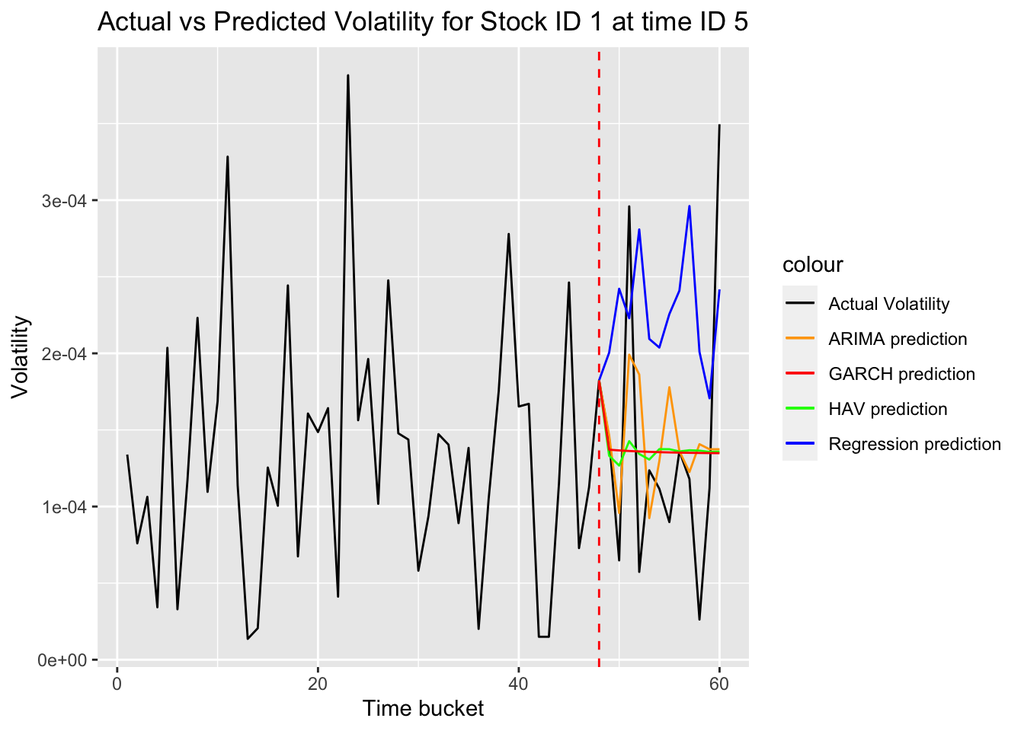

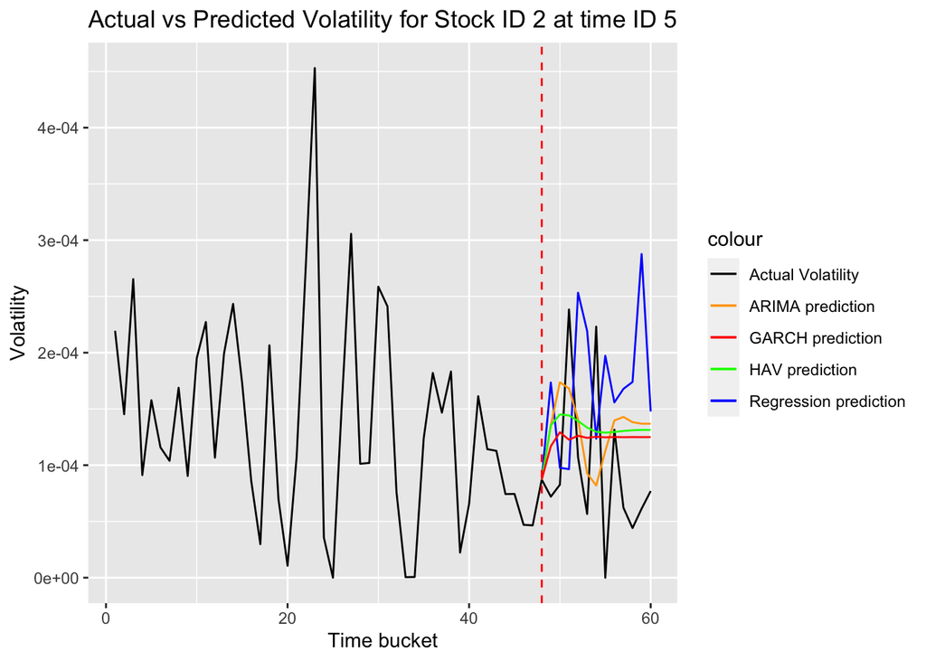

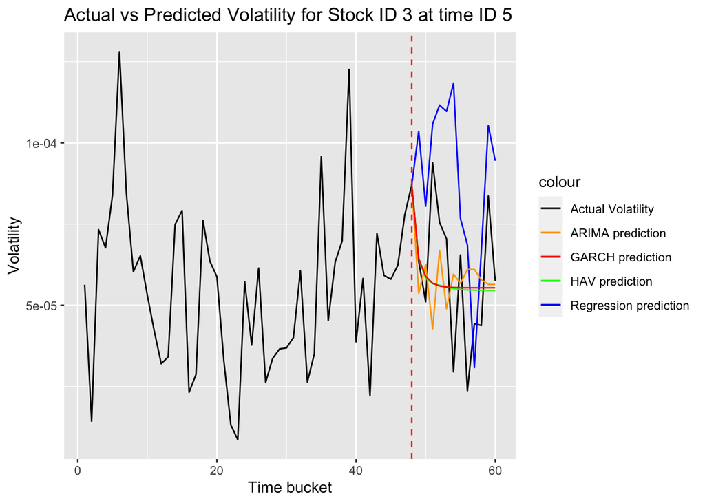

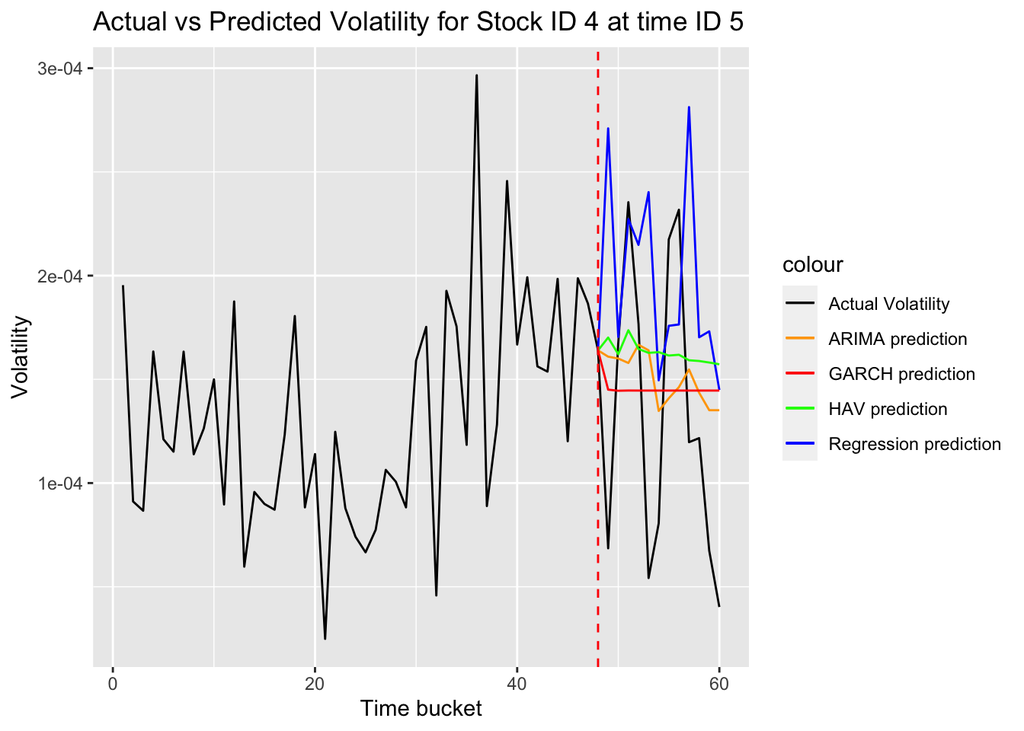

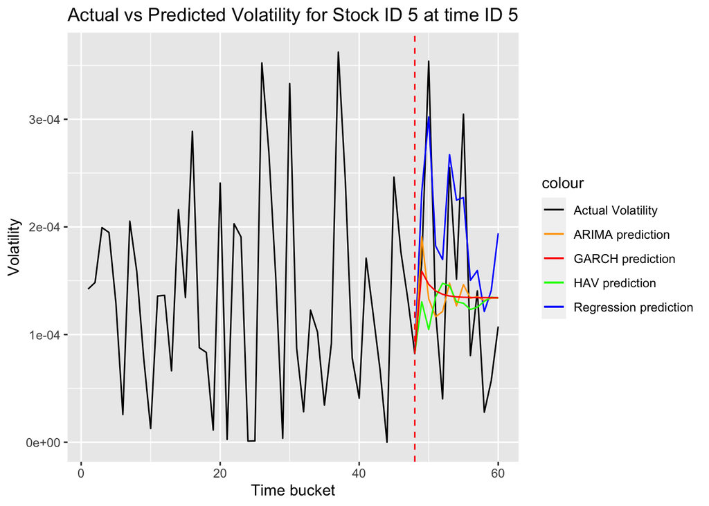

```r
for (i in 1 : 5){
  stock_idx = i
  time_idx = 1 # pick time id here
  time_id <- comm_time_IDs[[time_idx]]
  draw_res_plot(arima.pred.dic, reg.pred.dic.1, hav.pred.dic, garch.pred.dic, stock_idx, time_id)
}
```

### 4.2 Model evaluation

Define a `evaluate()` function. Take validation data and prediction data as input. Return a list of measurements containing “MSE”, “RMSE”, “MAE”, “QLIKE”.

```r
evaluate <- function(val.dic, pred.dic) {
  mse.dic <- list()
  rmse.dic <- list()
  mae.dic <- list()
  qlike.dic <- list()

  for (stock_id in stock_ids) {
    # Initialise a vector to store the metrices for each time id
    mse.vec <- rep(0, num.time.id)
    rmse.vec <- rep(0, num.time.id)
    mae.vec <- rep(0, num.time.id)
    qlike.vec <- rep(0, num.time.id)

    for (i in 1 : num.time.id) {
      pred <- pred.dic[[stock_id]][[i]]
      actual <- val.dic[[stock_id]][[i]]$volatility
      mse.vec[[i]] <- mse(actual, pred)
      rmse.vec[[i]] <- rmse(actual, pred)
      mae.vec[[i]] <- mae(actual, pred)
      qlike.vec[[i]] <- mean(actual/pred - log(actual/pred) - 1)
    }

    mse.dic[[stock_id]] <- mse.vec
    rmse.dic[[stock_id]] <- rmse.vec
    mae.dic[[stock_id]] <- mae.vec
    qlike.dic[[stock_id]] <- qlike.vec[is.finite(qlike.vec)]
  }
  return(list("MSE"=mse.dic, "RMSE"=rmse.dic, "MAE"=mae.dic, "QLIKE"=qlike.dic))
}
```

```r
# Convert the list of metrices to a dataframe (this is only for better showing the performance of one model in each stock)
get_metric_df <- function(res){
  ret_df <- data.frame(matrix(ncol = 5, nrow = 0))
  colnames(ret_df) <- c("MSE", "RMSE", "MAE", "QLIKE", "RMSE_sd")
  for (stock_id in stock_ids) {
    stock_mse <- mean(na.omit(unlist(res[[1]][[stock_id]])))
    stock_rmse <- mean(na.omit(unlist(res[[2]][[stock_id]])))
    stock_rmse_sd <- sd(na.omit(unlist(res[[2]][[stock_id]])))
    stock_mae <- mean(na.omit(unlist(res[[3]][[stock_id]])))
    qlike_lis <- na.omit(unlist(res[[4]][[stock_id]])) # Too many NA and Inf values for qlike, could have better approaches rather than just cleaning it
    stock_qlike <- mean(qlike_lis[is.finite(qlike_lis)])
    stock_df <- data.frame(MSE = stock_mse, RMSE = stock_rmse, MAE = stock_mae, QLIKE = stock_qlike, RMSE_sd = stock_rmse_sd)
    rownames(stock_df) <- (stock_id)
    ret_df <- rbind(ret_df, stock_df)
  }
  return(ret_df)
}
```

#### 4.2.1 ARIMA evaluation

```r
arima_res <- evaluate(vol.val.dic, arima.pred.dic)
arima_df <- get_metric_df(arima_res)
colMeans(arima_df)
```

```
##          MSE         RMSE          MAE        QLIKE      RMSE_sd
## 2.106127e-07 3.285753e-04 2.697426e-04 5.181838e-01 2.572759e-04
```

#### 4.2.2 Linear Regression evaluation

```r
reg_res_1 <- evaluate(vol.val.dic, reg.pred.dic.1)
reg_df_1 <- get_metric_df(reg_res_1)
colMeans(reg_df_1)
```

```
##          MSE         RMSE          MAE        QLIKE      RMSE_sd
## 1.797201e-07 3.088482e-04 2.457064e-04 3.250565e-01 2.312609e-04
```

#### 4.2.3 HAV evaluation

```r
hav_res <- evaluate(vol.val.dic, hav.pred.dic)
hav_df <- get_metric_df(hav_res)
colMeans(hav_df)
```

```
##          MSE         RMSE          MAE        QLIKE      RMSE_sd
## 1.755719e-07 3.006150e-04 2.484596e-04 3.460234e-01 2.333307e-04
```

#### 4.2.4 GARCH evaluation

```r
garch_res <- evaluate(vol.val.dic, garch.pred.dic)
garch_df <- get_metric_df(garch_res)
colMeans(garch_df)
```

```
##          MSE         RMSE          MAE        QLIKE      RMSE_sd
## 1.744101e-07 3.005423e-04 2.491800e-04 3.375761e-01 2.308168e-04
```

### 4.3 Model performance comparison across stocks

```r
# Compare the model performance at each stock using MSE
plot_performance <- function(arima_res, reg_res, hav_res, garch_res, stock_id, method_type="RMSE") {
  methods <- list("MSE" = 1, "RMSE" = 2, "MAE" = 3, "QLIKE" = 4)
  method_idx <- methods[[method_type]]
  arima_1 <- (unlist(arima_res[[method_idx]][[stock_id]]))
  reg_1 <- (unlist(reg_res_1[[method_idx]][[stock_id]]))
  hav_1 <- (unlist(hav_res[[method_idx]][[stock_id]]))
  garch_1 <- (unlist(garch_res[[method_idx]][[stock_id]]))

  # Combine the vectors into a list
  vectors <- list(arima_1, reg_1, hav_1, garch_1)
  names(vectors) = c("ARIMA", "Linear Regression", "HAV-RV", "GARCH")

  # Calculate means for each vector
  vector_means <- sapply(vectors, mean)

  # Identify the index of the lowest mean
  lowest_mean_idx <- which.min(vector_means)

  boxplot(vectors,
          names = names(vectors),
          col = ifelse(names(vectors) == names(vectors)[lowest_mean_idx], "red", "gray"),
          main = paste0("Models performance at stocks ", stock_id),
          ylab = method_type,
          outline = FALSE)
}
```

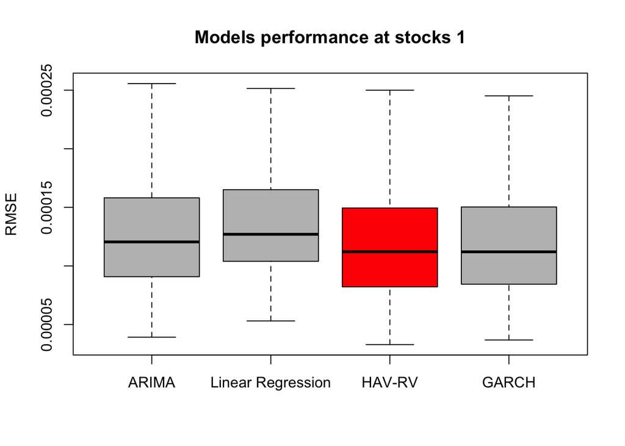

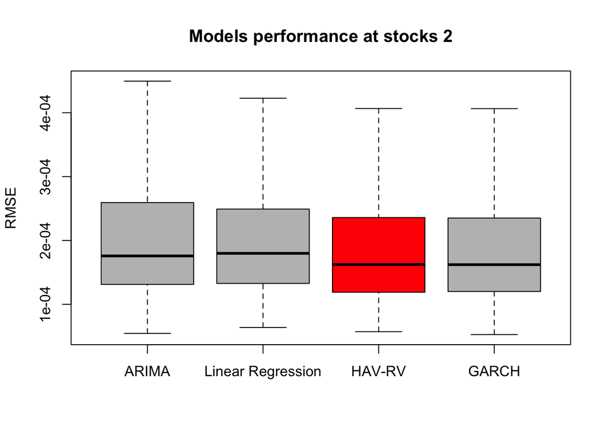

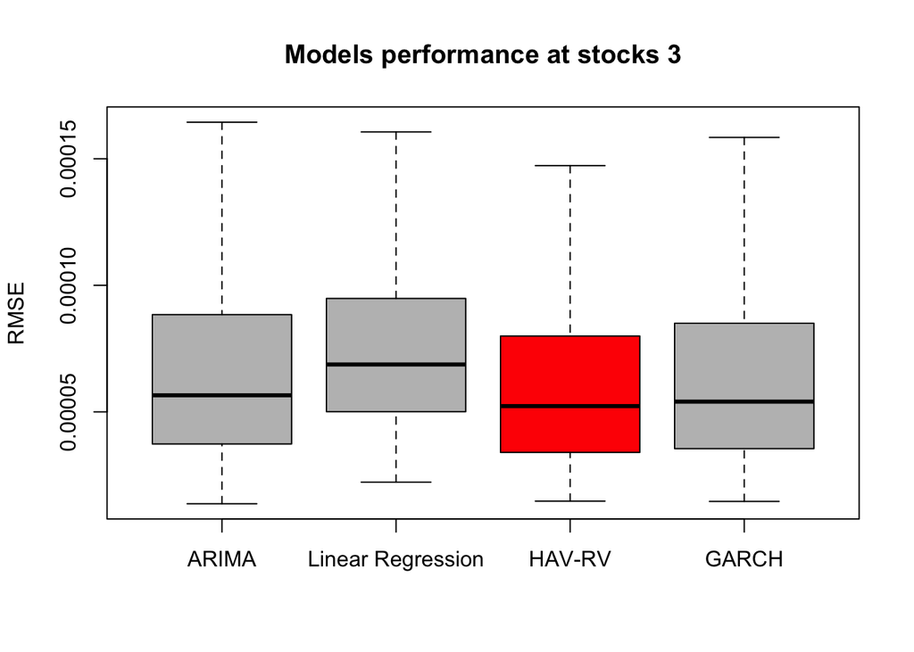

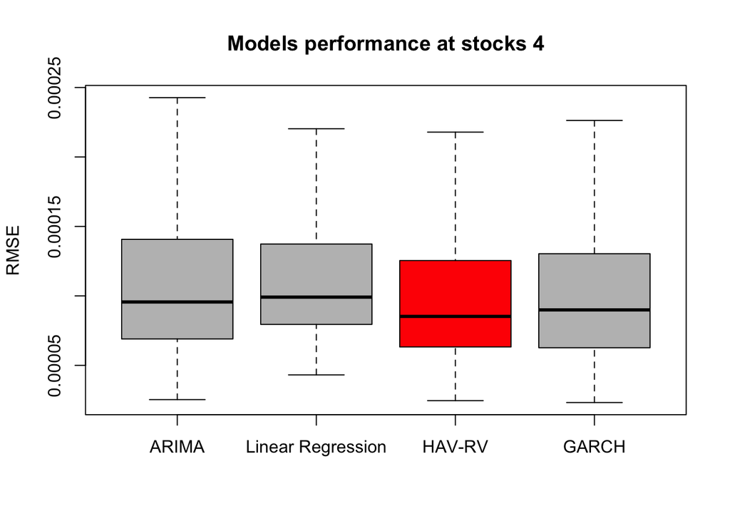

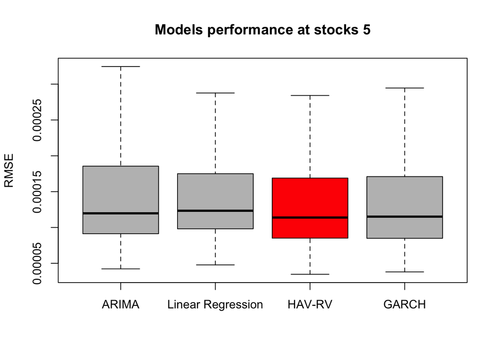

```r
for (i in 1 : 5){
  plot_performance(arima_res, reg_res_1, hav_res, garch_res, i, "RMSE")
}
```

### 4.4 Model performance comparison across clusters(classes) (RMSE)

```r
rmse_eval_table <- data.frame(matrix(ncol = 4, nrow = 0))
colnames(rmse_eval_table) <- c("ARIMA", "Regression", "HAV_RV", "ARMA_GARCH")
for (group in group_lis) {
  stocks <- as.character(group$stock_id)
  arima_rmse <- c()
  reg_rmse <- c()
  hav_rmse <- c()
  garch_rmse <- c()
  for (stock_id in stocks) {
    arima_rmse <- c(arima_rmse, arima_res[[2]][[stock_id]])
    reg_rmse <- c(reg_rmse, reg_res_1[[2]][[stock_id]])
    hav_rmse <- c(hav_rmse, hav_res[[2]][[stock_id]])
    garch_rmse <- c(garch_rmse, garch_res[[2]][[stock_id]])
  }
  row_df <- data.frame("ARIMA" = mean(arima_rmse, na.rm = TRUE),
                       "Regression" = mean(reg_rmse, na.rm = TRUE),
                       "HAV_RV" = mean(hav_rmse, na.rm = TRUE),
                       "ARMA_GARCH" = mean(garch_rmse, na.rm = TRUE))
  rownames(row_df) <- paste0("Cluster", as.character(group$cluster[1]))
  rmse_eval_table <- rbind(rmse_eval_table, row_df)
}
rmse_eval_table
```

```
##                  ARIMA   Regression       HAV_RV   ARMA_GARCH
## Cluster1  0.0001482801 0.0001504679 0.0001353389 0.0001362416
## Cluster2  0.0002371653 0.0002243619 0.0002183375 0.0002186580
## Cluster3  0.0004010538 0.0003677070 0.0003671423 0.0003669409
## Cluster4  0.0007021186 0.0006483291 0.0006460351 0.0006442480
## Cluster5  0.0003254442 0.0003044817 0.0002962375 0.0002960000
## Cluster6  0.0001952481 0.0002009092 0.0001796499 0.0001809169
## Cluster7  0.0005533119 0.0005047172 0.0005048327 0.0005036782
## Cluster8  0.0004505853 0.0004195719 0.0004130038 0.0004117315
## Cluster9  0.0001855666 0.0001807640 0.0001696492 0.0001692006
## Cluster10 0.0002254478 0.0002018449 0.0001942437 0.0001938938
```

### 4.5 Model comparison with different metrics over predictions made by all trained stocks

Calculate RMSE(mean), RMSE(sd), QLIKE(mean) for four models over all predictions.

```r
arima_rmse <- unlist(arima_res[[2]])
reg_rmse <- unlist(reg_res_1[[2]])
hav_rmse <- unlist(hav_res[[2]])
garch_rmse <- unlist(garch_res[[2]])

arima_mae <- unlist(arima_res[[3]])
reg_mae <- unlist(reg_res_1[[3]])
hav_mae <- unlist(hav_res[[3]])
garch_mae <- unlist(garch_res[[3]])

arima_qlike <- unlist(arima_res[[4]])
reg_qlike <- unlist(reg_res_1[[4]])
hav_qlike <- unlist(hav_res[[4]])
garch_qlike <- unlist(garch_res[[4]])

arima_rmse_mean <- mean(arima_rmse, na.rm = TRUE)
reg_rmse_mean <- mean(reg_rmse, na.rm = TRUE)
hav_rmse_mean <- mean(hav_rmse, na.rm = TRUE)
garch_rmse_mean <- mean(garch_rmse, na.rm = TRUE)

arima_rmse_sd <- sd(arima_rmse, na.rm = TRUE)
reg_rmse_sd <- sd(reg_rmse, na.rm = TRUE)
hav_rmse_sd <- sd(hav_rmse, na.rm = TRUE)
garch_rmse_sd <- sd(garch_rmse, na.rm = TRUE)

arima_qlike_mean <- mean(arima_qlike, na.rm = TRUE)
reg_qlike_mean <- mean(reg_qlike, na.rm = TRUE)
hav_qlike_mean <- mean(hav_qlike, na.rm = TRUE)
garch_qlike_mean <- mean(garch_qlike, na.rm = TRUE)

metrics_df <- data.frame(
  "RMSE(mean)" = c(arima_rmse_mean, reg_rmse_mean, hav_rmse_mean, garch_rmse_mean),
  "RMSE(sd)" = c(arima_rmse_sd, reg_rmse_sd, hav_rmse_sd, garch_rmse_sd),
  "QLIKE(mean)" = c(arima_qlike_mean, reg_qlike_mean, hav_qlike_mean, garch_qlike_mean)
)
rownames(metrics_df) <- c("ARIMA", "Linear.Regression", "HAV.RV", "ARMA.GARCH")
```

Calculate AIC(mean).

```r
arima_aic_vec <- c()
reg_aic_vec <- c()
hav_aic_vec <- c()
garch_aic_vec <- c()
for (stock_id in stock_ids) {
  for (i in 1: num.time.id) {
    arima_aic_vec <- c(arima_aic_vec, AIC(arima.model.dic[[stock_id]][[i]]))
    hav_aic_vec <- c(hav_aic_vec, AIC(hav.model.dic[[stock_id]][[i]]))
    garch_aic_vec <- c(garch_aic_vec, infocriteria(garch.model.dic[[stock_id]][[i]])[1])
  }
  reg_aic_vec <- c(reg_aic_vec, AIC(linear.model.dic.1[[stock_id]]))
}
metrics_df$AIC.mean. <- c(mean(arima_aic_vec), mean(reg_aic_vec), mean(hav_aic_vec), mean(garch_aic_vec))
```

Print the metrics data frame.

```r
metrics_df
```

```
##                     RMSE.mean.     RMSE.sd. QLIKE.mean.    AIC.mean.
## ARIMA             0.0003285753 0.0003203990   0.4397590    -658.2101
## Linear.Regression 0.0003088482 0.0002904077   0.2763081 -302624.9881
## HAV.RV            0.0003006150 0.0002919013   0.2851516    -594.2187
## ARMA.GARCH        0.0003005423 0.0002899796   0.2809206     -13.5797
```

Overall model performance comparison using RMSE.

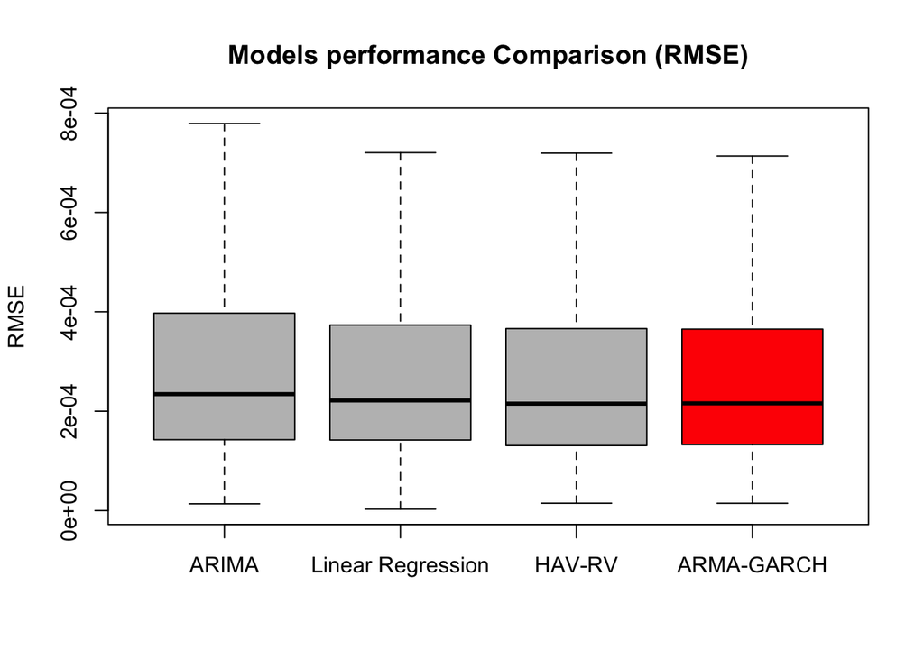

```r
# RMSE
vectors <- list(arima_rmse, reg_rmse, hav_rmse, garch_rmse)
names(vectors) <- c("ARIMA", "Linear Regression", "HAV-RV", "ARMA-GARCH")
# Calculate means for each vector
vector_means <- sapply(vectors, mean)
# Identify the index of the lowest mean
lowest_mean_idx <- which.min(vector_means)
boxplot(vectors,
          names = names(vectors),
          main = ("Models performance Comparison (RMSE)"),
          col = ifelse(names(vectors) == names(vectors)[lowest_mean_idx], "red", "gray"),
          ylab = "RMSE",
          outline = FALSE)
```

Overall model performance comparison using QLIKE.

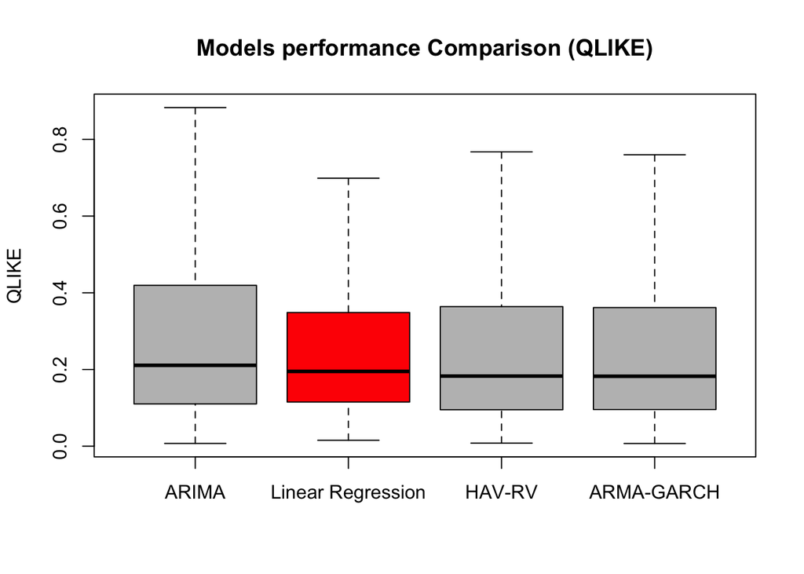

```r
# QLIKE
vectors <- list(arima_qlike, reg_qlike, hav_qlike, garch_qlike)
names(vectors) <- c("ARIMA", "Linear Regression", "HAV-RV", "ARMA-GARCH")
# Calculate means for each vector
vector_means <- sapply(vectors, mean)
# Identify the index of the lowest mean
lowest_mean_idx <- which.min(vector_means)
boxplot(vectors,
          names = names(vectors),
          main = ("Models performance Comparison (QLIKE)"),
          col = ifelse(names(vectors) == names(vectors)[lowest_mean_idx], "red", "gray"),
          ylab = "QLIKE",
          outline = FALSE)
```